# Proyecto

Edgar Leal

27/2/2021

```r
## Load recount3 R package
library("recount3")
human_projects <- available_projects()
```

```
## 2021-03-01 03:51:29 caching file sra.recount_project.MD.gz.
```

```
## 2021-03-01 03:51:30 caching file gtex.recount_project.MD.gz.
```

```
## 2021-03-01 03:51:31 caching file tcga.recount_project.MD.gz.
```

```r
proj_info <- subset(
    human_projects,
    project == "BRCA" & project_type == "data_sources"
)
## Crea un objeto de tipo RangedSummarizedExperiment (RSE)

rse_gene_BRCA <- create_rse(proj_info)
```

```
## 2021-03-01 03:51:40 downloading and reading the metadata.
```

```
## 2021-03-01 03:51:43 caching file tcga.tcga.BRCA.MD.gz.
```

```
## 2021-03-01 03:51:44 caching file tcga.recount_project.BRCA.MD.gz.
```

```
## 2021-03-01 03:51:45 caching file tcga.recount_qc.BRCA.MD.gz.
```

```
## 2021-03-01 03:51:46 caching file tcga.recount_seq_qc.BRCA.MD.gz.
```

```
## 2021-03-01 03:51:49 downloading and reading the feature information.
```

```
## 2021-03-01 03:51:49 caching file human.gene_sums.G026.gtf.gz.
```

```
## 2021-03-01 03:51:51 downloading and reading the counts: 1256 samples across 63856 features.
```

```
## 2021-03-01 03:51:52 caching file tcga.gene_sums.BRCA.G026.gz.
```

```
## 2021-03-01 03:52:20 construcing the RangedSummarizedExperiment (rse) object.
```

```r
rse_gene_BRCA
```

```
## class: RangedSummarizedExperiment
## dim: 63856 1256
## metadata(8): time_created recount3_version ... annotation recount3_url
## assays(1): raw_counts
## rownames(63856): ENSG00000278704.1 ENSG00000277400.1 ...
##   ENSG00000182484.15_PAR_Y ENSG00000227159.8_PAR_Y
## rowData names(10): source type ... havana_gene tag
## colnames(1256): 0b1cf6de-f98f-4020-baa7-c4fc518e5f00
##   20c90e97-e900-488e-af6a-6648d9a8bb01 ...
##   a340e38d-af36-4b13-add3-50be6819d4fe
##   a79dd5b2-f97a-4b24-b762-fea1cd5238fe
## colData names(937): rail_id external_id ... recount_seq_qc.errq
##   BigWigURL
```

```r
##Explorar el objeto
#dim(rse_gene_BRCA)
#head(dimnames(rse_gene_BRCA))
#rowRanges(rse_gene_BRCA)
#colData(rse_gene_BRCA)
#rse_gene_BRCA$melanoma
```

```r
assay(rse_gene_BRCA, "counts") <- compute_read_counts(rse_gene_BRCA)
```

```r
rse_gene_BRCA
```

```
## class: RangedSummarizedExperiment
## dim: 63856 1256
## metadata(8): time_created recount3_version ... annotation recount3_url
## assays(2): raw_counts counts
## rownames(63856): ENSG00000278704.1 ENSG00000277400.1 ...
##   ENSG00000182484.15_PAR_Y ENSG00000227159.8_PAR_Y
## rowData names(10): source type ... havana_gene tag
## colnames(1256): 0b1cf6de-f98f-4020-baa7-c4fc518e5f00
##   20c90e97-e900-488e-af6a-6648d9a8bb01 ...
##   a340e38d-af36-4b13-add3-50be6819d4fe
##   a79dd5b2-f97a-4b24-b762-fea1cd5238fe
## colData names(937): rail_id external_id ... recount_seq_qc.errq
##   BigWigURL
```

```r
##Explorar los datos y graficarlos
library("iSEE")
iSEE::iSEE(rse_gene_BRCA)
```

Shiny applications not supported in static R Markdown documents

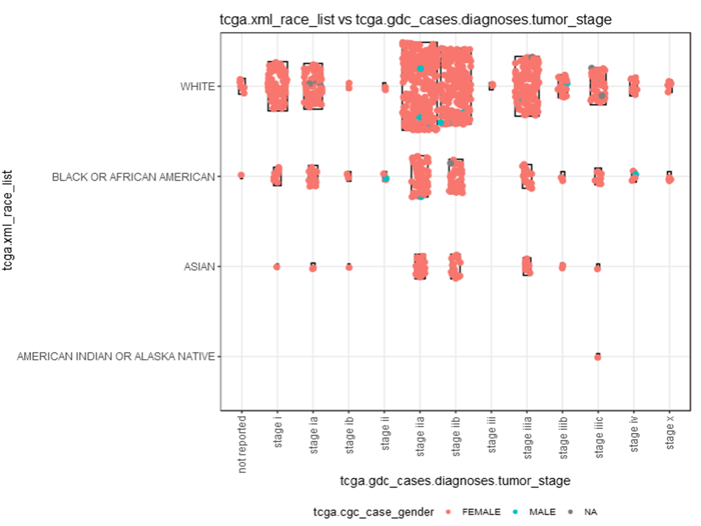

Estadios del cancer según la raza

En la imagen podemos observar que la raza blanca es la que mayor incidencia de cáncer de mama; mientras que las razas nativas americanas no se ven tan afectadas por este tipo de cáncer. Además, podemos ver que la raza asiática tiene menor incidencia de cáncer de mama por BRCA en sus estadios más avanzados

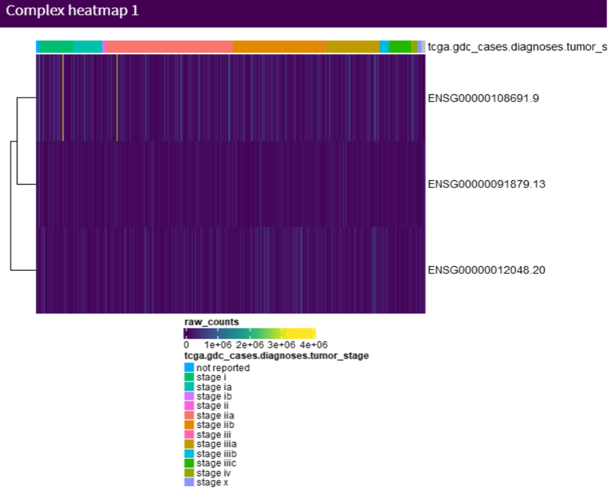

Expresión diferencial de BRCA1, ANGPT2, CCL2

Se puede observar que al clusterizar, los genes ANGPT2 y CCl2 están mas relacionados entre sí que BRCA1, esto debido a que ambos son genes involucrados en metástasis. Sin embargo, no hubo DE significativa comparado entre estadios avanzados e iniciales, contrario a lo que esperaria, especialmente con ANGPT2 y CCL2 debido a su rol en angiogénesis y respuesta inmune respectivamente, y que ayuda a la metástasis. [genes implicados en metastasis cerebral](https://www.sciencedirect.com/science/article/pii/S0304383508008896?casa_token=kGj2RtqfzJwAAAAA:PvTcsePbxomwIoPUznF24XOgQbuvzt97CTFOveqdoqUBMKsTcJt5mn3A11A1aTyCU4B9hgUU6_l_) a partir de cáncer de mama

```r
#Quitar los NA
rse_gene_BRCA$tcga.cgc_case_tumor_status[is.na(rse_gene_BRCA$tcga.cgc_case_tumor_status)] <- 'x'
rse_gene_BRCA$tcga.gdc_cases.diagnoses.tumor_stage[is.na(rse_gene_BRCA$tcga.gdc_cases.diagnoses.tumor_stage)] <- 'x'
rse_gene_BRCA$`recount_qc.bc_auc.all_%`[is.na(rse_gene_BRCA$`recount_qc.bc_auc.all_%`)] <- 0
rse_gene_BRCA$tcga.xml_race_list[is.na(rse_gene_BRCA$tcga.xml_race_list)] <- 'x'
rse_gene_BRCA$recount_qc.gene_fc_count_all.assigned[is.na(rse_gene_BRCA$recount_qc.gene_fc_count_all.assigned)] <- 'x'
```

```r
rse_gene_BRCA$tcga.cgc_slide_percent_lymphocyte_infiltration <- as.numeric(rse_gene_BRCA$tcga.cgc_slide_percent_lymphocyte_infiltration)
rse_gene_BRCA$tcga.gdc_cases.diagnoses.tumor_stage <- factor(rse_gene_BRCA$tcga.gdc_cases.diagnoses.tumor_stage)
rse_gene_BRCA$tcga.cgc_case_tumor_status <- factor(rse_gene_BRCA$tcga.cgc_case_tumor_status)
#Las comillas escapan al símbolo %
rse_gene_BRCA$`recount_qc.bc_auc.all_%`<-as.numeric(rse_gene_BRCA$`recount_qc.bc_auc.all_%`)
##auc is area under the curve, is a metric in transcriptomics
rse_gene_BRCA$tcga.xml_race_list <- factor(rse_gene_BRCA$tcga.xml_race_list)
rse_gene_BRCA$recount_qc.gene_fc_count_all.assigned <- as.numeric(rse_gene_BRCA$recount_qc.gene_fc_count_all.assigned)
```

```r
summary(rse_gene_BRCA$`recount_qc.bc_auc.all_%`)
```

```
##    Min. 1st Qu.  Median    Mean 3rd Qu.    Max.
##   82.37  138.96  140.87  140.60  143.19  158.33
```

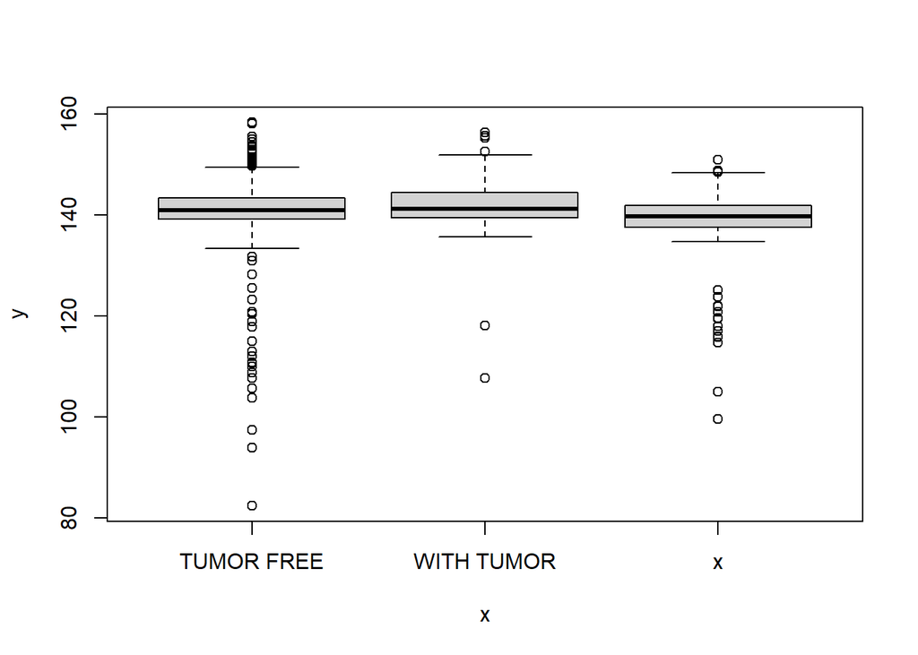

```r
with(colData(rse_gene_BRCA), plot(tcga.cgc_case_tumor_status, `recount_qc.bc_auc.all_%`))
```

```r
##Diferencias entre tumor y free tumor

with(colData(rse_gene_BRCA), tapply( `recount_qc.bc_auc.all_%`,tcga.cgc_case_tumor_status,summary))
```

```
## $`TUMOR FREE`
##    Min. 1st Qu.  Median    Mean 3rd Qu.    Max.
##   82.37  139.18  140.97  140.85  143.36  158.33
##
## $`WITH TUMOR`
##    Min. 1st Qu.  Median    Mean 3rd Qu.    Max.
##   107.7   139.4   141.2   141.7   144.5   156.4
##
## $x
##    Min. 1st Qu.  Median    Mean 3rd Qu.    Max.
##   99.61  137.55  139.79  138.40  141.91  151.00
```

```r
##Diferencias entre clasificaciones

with(colData(rse_gene_BRCA), tapply(`recount_qc.bc_auc.all_%`,tcga.gdc_cases.diagnoses.tumor_stage,summary))
```

```
## $`not reported`
##    Min. 1st Qu.  Median    Mean 3rd Qu.    Max.
##   136.0   137.9   139.2   138.9   139.8   141.3
##
## $`stage i`
##    Min. 1st Qu.  Median    Mean 3rd Qu.    Max.
##   120.8   138.8   140.2   140.8   142.8   158.2
##
## $`stage ia`
##    Min. 1st Qu.  Median    Mean 3rd Qu.    Max.
##   114.7   139.3   140.6   140.4   143.6   155.6
##
## $`stage ib`
##    Min. 1st Qu.  Median    Mean 3rd Qu.    Max.
##   138.0   140.3   141.7   141.4   142.1   144.8
##
## $`stage ii`
##    Min. 1st Qu.  Median    Mean 3rd Qu.    Max.
##   137.6   139.3   141.4   141.1   142.7   144.3
##
## $`stage iia`
##    Min. 1st Qu.  Median    Mean 3rd Qu.    Max.
##    97.4   138.8   141.0   140.4   143.2   153.0
##
## $`stage iib`
##    Min. 1st Qu.  Median    Mean 3rd Qu.    Max.
##   82.37  138.79  140.82  140.41  143.12  158.33
##
## $`stage iii`
##    Min. 1st Qu.  Median    Mean 3rd Qu.    Max.
##   137.3   138.4   139.4   139.4   140.4   141.5
##
## $`stage iiia`
##    Min. 1st Qu.  Median    Mean 3rd Qu.    Max.
##   105.6   139.0   140.8   141.1   143.2   154.4
##
## $`stage iiib`
##    Min. 1st Qu.  Median    Mean 3rd Qu.    Max.
##   136.5   139.3   140.8   141.6   143.1   152.7
##
## $`stage iiic`
##    Min. 1st Qu.  Median    Mean 3rd Qu.    Max.
##   136.6   139.7   141.6   142.1   143.7   155.7
##
## $`stage iv`
##    Min. 1st Qu.  Median    Mean 3rd Qu.    Max.
##   112.0   140.6   142.2   141.8   145.0   148.9
##
## $`stage x`
##    Min. 1st Qu.  Median    Mean 3rd Qu.    Max.
##   136.5   139.6   141.2   141.7   141.9   156.4
##
## $x
##    Min. 1st Qu.  Median    Mean 3rd Qu.    Max.
##   99.61  117.50  138.35  129.50  140.43  142.02
```

Se puede observar que no existen diferencias significativas por lo que vamos a quitar muestras no informativas

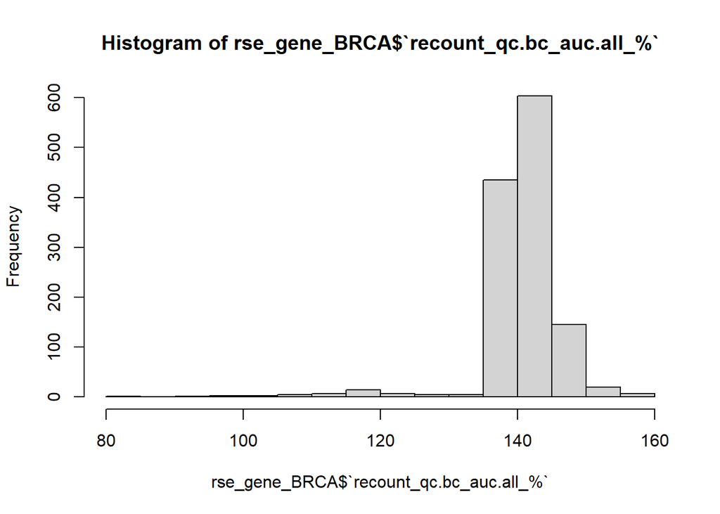

```r
## Guardemos nuestro objeto entero
rse_gene_BRCA_unfiltered <- rse_gene_BRCA
##Graficar para ver un umbral adecuado
hist(rse_gene_BRCA$`recount_qc.bc_auc.all_%`)
```

```r
##Visualizar cuantas muestras no alcanzan el umbral
table(rse_gene_BRCA$`recount_qc.bc_auc.all_%` < 130)
```

```
##
## FALSE  TRUE
##  1214    42
```

```r
rse_gene_BRCA <- rse_gene_BRCA[, rse_gene_BRCA$`recount_qc.bc_auc.all_%` > 130]
```

```r
##Eliminando genes
gene_means <- rowMeans(assay(rse_gene_BRCA, "counts"))
summary(gene_means)
```

```
##     Min.  1st Qu.   Median     Mean  3rd Qu.     Max.
##      0.0      0.1      2.9   1090.0    264.9 716251.8
```

```r
#Se eliminará genes debajo del quartile 1

## Eliminamos genes
rse_gene_BRCA <- rse_gene_BRCA[gene_means > 1.4, ]

## Dimensiones finales
dim(rse_gene_BRCA)
```

```
## [1] 34864  1214
```

```r
library("edgeR")
rse_gene_BRCA_unfiltered
```

```
## class: RangedSummarizedExperiment
## dim: 63856 1256
## metadata(8): time_created recount3_version ... annotation recount3_url
## assays(2): raw_counts counts
## rownames(63856): ENSG00000278704.1 ENSG00000277400.1 ...
##   ENSG00000182484.15_PAR_Y ENSG00000227159.8_PAR_Y
## rowData names(10): source type ... havana_gene tag
## colnames(1256): 0b1cf6de-f98f-4020-baa7-c4fc518e5f00
##   20c90e97-e900-488e-af6a-6648d9a8bb01 ...
##   a340e38d-af36-4b13-add3-50be6819d4fe
##   a79dd5b2-f97a-4b24-b762-fea1cd5238fe
## colData names(937): rail_id external_id ... recount_seq_qc.errq
##   BigWigURL
```

```r
## Porcentaje de genes que retuvimos
round(nrow(rse_gene_BRCA) / nrow(rse_gene_BRCA_unfiltered) * 100, 2)
```

```
## [1] 54.6
```

```r
dge <- DGEList(
    counts = assay(rse_gene_BRCA, "counts"),
    genes = rowData(rse_gene_BRCA)
)
dge <- calcNormFactors(dge)
```

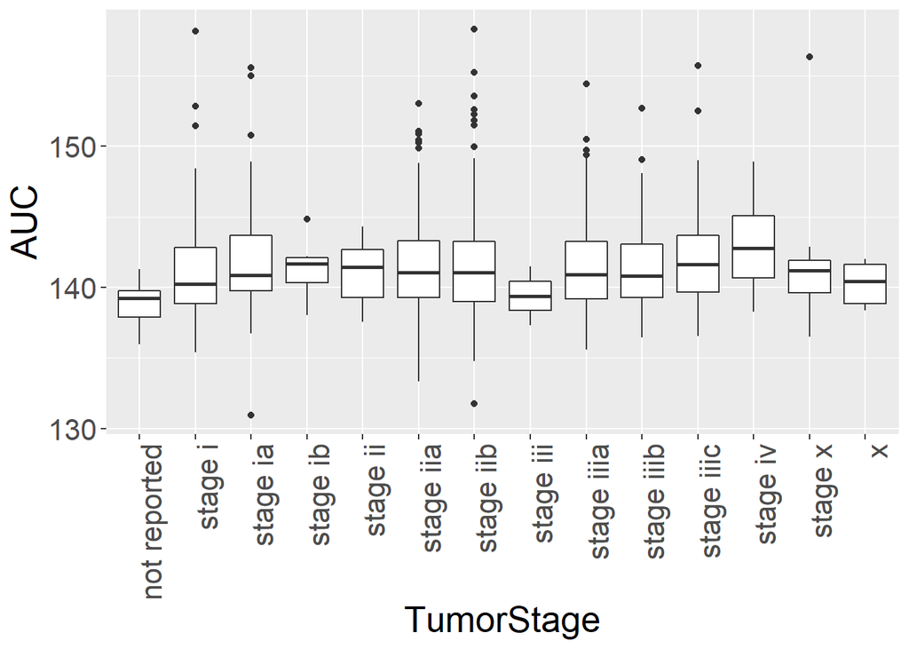

```r
library("ggplot2")
ggplot(as.data.frame(colData(rse_gene_BRCA)), aes(y = rse_gene_BRCA$`recount_qc.bc_auc.all_%`,
                                                  x = rse_gene_BRCA$tcga.gdc_cases.diagnoses.tumor_stage)) +
    geom_boxplot() +
  ylab("AUC") +
    xlab("TumorStage")+
    theme(text = element_text(size=20),
          axis.text.x = element_text(angle=90, hjust=1))
```

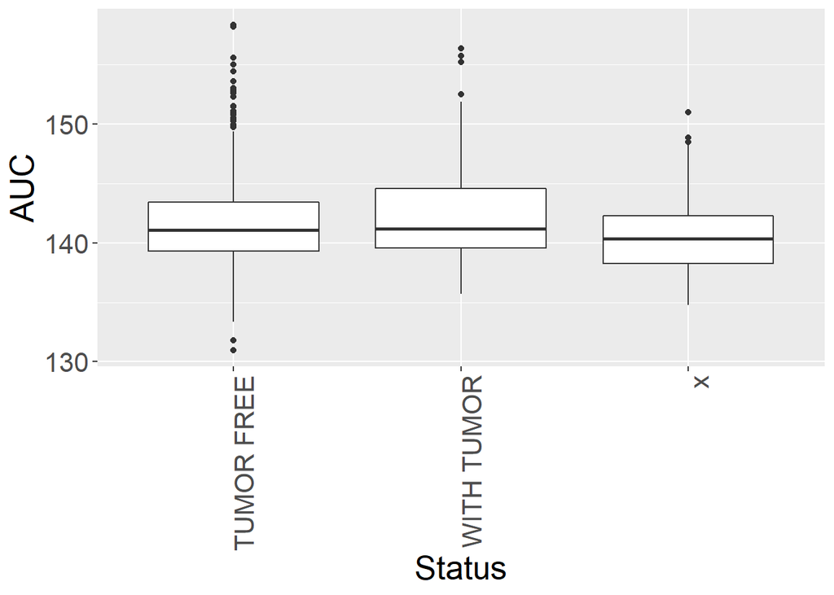

```r
library("ggplot2")
ggplot(as.data.frame(colData(rse_gene_BRCA)), aes(y = rse_gene_BRCA$`recount_qc.bc_auc.all_%`,
                                                  x = rse_gene_BRCA$tcga.cgc_case_tumor_status)) +
    geom_boxplot() +
  ylab("AUC") +
    xlab("Status")+
    theme(text = element_text(size=20),
          axis.text.x = element_text(angle=90, hjust=1))
```

```r
mod <- model.matrix(~ rse_gene_BRCA$tcga.cgc_case_tumor_status + rse_gene_BRCA$`recount_qc.bc_auc.all_%`  + rse_gene_BRCA$tcga.gdc_cases.diagnoses.tumor_stage + rse_gene_BRCA$tcga.xml_race_list,
    data = colData(rse_gene_BRCA)
)
#colnames(mod)
```

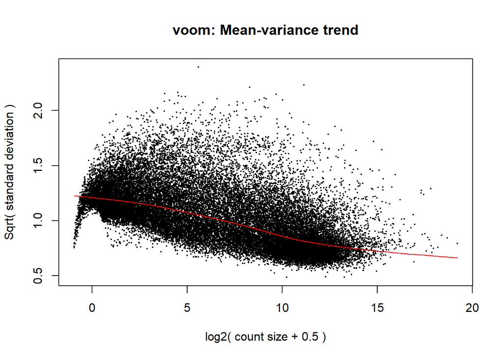

```r
library("limma")

vGene <- voom(dge, mod, plot = TRUE)
```

```r
eb_results <- eBayes(lmFit(vGene))

de_results <- topTable(
    eb_results,
    coef = 2,
    number = nrow(rse_gene_BRCA),
    sort.by = "none"
)
dim(de_results)
```

```
## [1] 34864    16
```

```r
head(de_results)
```

```
##                    source type score phase           gene_id
## ENSG00000223972.5  HAVANA gene  1735    NA ENSG00000223972.5
## ENSG00000278267.1 ENSEMBL gene    68    NA ENSG00000278267.1
## ENSG00000227232.5  HAVANA gene  1351    NA ENSG00000227232.5
## ENSG00000243485.5  HAVANA gene  1021    NA ENSG00000243485.5
## ENSG00000239945.1  HAVANA gene  1319    NA ENSG00000239945.1
## ENSG00000238009.6  HAVANA gene  3726    NA ENSG00000238009.6
##                                            gene_type    gene_name level
## ENSG00000223972.5 transcribed_unprocessed_pseudogene      DDX11L1     2
## ENSG00000278267.1                              miRNA    MIR6859-1     3
## ENSG00000227232.5             unprocessed_pseudogene       WASH7P     2
## ENSG00000243485.5                            lincRNA  MIR1302-2HG     2
## ENSG00000239945.1                            lincRNA RP11-34P13.8     2
## ENSG00000238009.6                            lincRNA RP11-34P13.7     2
##                            havana_gene               tag       logFC    AveExpr
## ENSG00000223972.5 OTTHUMG00000000961.2              <NA> -0.04488977 -2.8337435
## ENSG00000278267.1                 <NA>              <NA> -0.21586505 -3.9566828
## ENSG00000227232.5 OTTHUMG00000000958.1              <NA>  0.01451433  3.1662522
## ENSG00000243485.5 OTTHUMG00000000959.2        ncRNA_host  0.09228721 -4.8032486
## ENSG00000239945.1 OTTHUMG00000001097.2 overlapping_locus  0.18868283 -1.1805234
## ENSG00000238009.6 OTTHUMG00000001096.2 overlapping_locus  0.22020066 -0.3412772
##                            t   P.Value adj.P.Val         B
## ENSG00000223972.5 -0.2967431 0.7667141 0.9397530 -5.431636
## ENSG00000278267.1 -1.5531680 0.1206473 0.5361707 -4.447460
## ENSG00000227232.5  0.2513898 0.8015559 0.9504606 -5.862454
## ENSG00000243485.5  0.6343870 0.5259495 0.8494007 -5.241189
## ENSG00000239945.1  1.9879659 0.0470429 0.4011713 -3.873569
## ENSG00000238009.6  2.5744620 0.0101589 0.2468296 -2.738718
```

```r
## Genes diferencialmente expresados entre tumor y free tumor con FDR < 5%
table(de_results$adj.P.Val < 0.05)
```

```
##
## FALSE  TRUE
## 34862     2
```

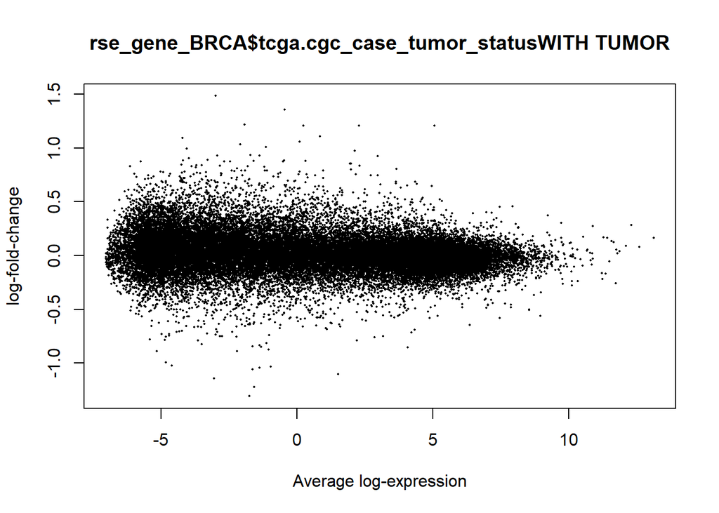

```r
## Visualicemos los resultados estadísticos
limma::plotMA(eb_results, coef = 2)
```

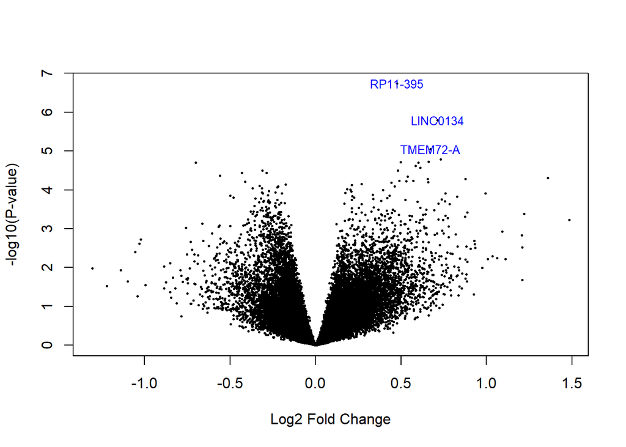

```r
volcanoplot(eb_results, coef = 2, highlight = 3, names = de_results$gene_name)
```

```r
iSEE::iSEE(rse_gene_BRCA)
```

Shiny applications not supported in static R Markdown documents

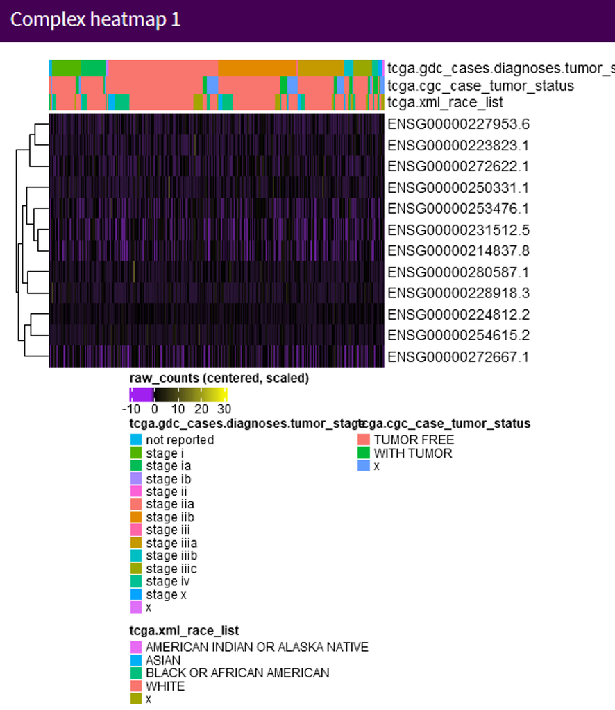